# CA1: Data Analysis of Singapore's University Graduates

Name: Jovian Sanjaya Putra

Admin Number: 2233570

Module Class: EP0302FT04

# 1) What are the factors affecting post graduate salaries?

# Data Sets

```python
import numpy as np
import matplotlib.pyplot as plt
import matplotlib.colors as mcolors
import pandas as pd

#Graduate Employment Survey
#https://beta.data.gov.sg/collections/415/view
file1_csv="GraduateEmploymentSurveyNTUNUSSITSMUSUSSSUTD.csv"
df = pd.read_csv(file1_csv)
df['school']=(df['school'].replace(',',' ', regex=True))
df['degree']=(df['degree'].replace('#',' ', regex=True))
df['degree']=(df['degree'].replace(',',' ', regex=True))
df.to_csv('ges.csv')
file1_csv_clean="ges.csv"
employment = np.genfromtxt(file1_csv_clean,delimiter=',',
                           names = True, missing_values=['na','-'],
                           filling_values=0,comments=None,
                           dtype=[int,'U30','U30','U30',float,float,int,int,int,int,int,int,int])


#Enrolment by Institutions
#https://beta.data.gov.sg/collections/452/datasets/d_ec8a16e11a050f11880fb6d4a0e6f93f/view
file2_csv = "EnrolmentbyInstitutions.csv"
enrollment = np.genfromtxt(file2_csv,delimiter=',',names=True, missing_values=['na','-'],
                              filling_values=0,comments=None,
                              dtype=[int,'U10', int,int,int,int,int,int,int,int,int,int,int,int,int,int,int,int,int])




#Graduates by Institutions
#https://beta.data.gov.sg/collections/452/datasets/d_06067a3d18f8a5779acfbf19c62cb656/view
file3_csv = "GraduatesbyInstitutions.csv"
graduates= np.genfromtxt(file3_csv,delimiter=',',names=True, missing_values=['na','-'],
                             filling_values=0,comments=None,
                             dtype=[int,'U10', int,int,int,int,int,int,int,int,int,int,int,int,int,int,int,int,int])
```

# Data Set 1

The data set provides the graduate employment information such as employment rate, basic salaries, gross salaries from different universities over 9 years (2013 - 2021)

The universities inlcude Nanyang Technological University (NTU), National University Singapore (NUS), Singapore Institute of Technology (SIT), Singapore Management University (SMU), Singapore University of Social Science (SUSS), Singapore University of Technology and Design (SUTD)

Since data set 1 contains character such as "#" and ",", hence i have to clean the data before using it.

```python
print(f"There are {len(employment)} rows and {len(employment[0])} columns in the data set 'GraduateEmploymentSurveyNTUNUSSITSMUSUSSSUTD'")
```

```
There are 1121 rows and 13 columns in the data set 'GraduateEmploymentSurveyNTUNUSSITSMUSUSSSUTD'
```

```python
print(f"The names of the columns are {employment.dtype.names}")
```

```
The names of the columns are ('f0', 'year', 'university', 'school', 'degree', 'employment_rate_overall', 'employment_rate_ft_perm', 'basic_monthly_mean', 'basic_monthly_median', 'gross_monthly_mean', 'gross_monthly_median', 'gross_mthly_25_percentile', 'gross_mthly_75_percentile')
```

```python
print(f"There are total of {np.unique(employment['university']).size} different universities with {np.unique(employment['school']).size} different schools in the data sets")
```

```
There are total of 6 different universities with 63 different schools in the data sets
```

# Data Set 2

The data sets provide the number of enrolments by institutions from 1982 to 2021.However, we only use data from 2013 - 2021 in our analysis.

Since our analysis only involves university, I will not use the data on diploma education

```python
print(f"There are {len(enrollment)} rows and {len(enrollment[0])} columns in the data set 'EnrolmentbyInstitutions.csv'.")
```

```
There are 80 rows and 19 columns in the data set 'EnrolmentbyInstitutions.csv'.
```

```python
print(f"The names of the columns are {enrollment.dtype.names}")
```

```
The names of the columns are ('year', 'sex', 'nus', 'ntu', 'smu', 'sit', 'sutd', 'suss', 'nie', 'singapore_polytechnic', 'ngee_ann_polytechnic', 'temasek_polytechnic', 'nanyang_polytechnic', 'republic_polytechnic', 'lasalle_diploma', 'lasalle_degree', 'nafa_diploma', 'nafa_degree', 'ite')
```

```python
print(f"However, only university education {enrollment.dtype.names[3:9]} , {enrollment.dtype.names[15]}, and {enrollment.dtype.names[17]} is used")
```

```
However, only university education ('ntu', 'smu', 'sit', 'sutd', 'suss', 'nie') , lasalle_degree, and nafa_degree is used
```

# Data Set 3

The data set provides the number of graduates by institutios from 1983 to 2021. However, we only use data from 2013 - 2021 in our analysis.

This data set is similar to data set 2 which only use universities in the analysis.

```python
print(f"There are {len(graduates)} rows and {len(graduates[0])} columns in the data set 'GraduatesbyInstitutions.csv'.")
```

```
There are 78 rows and 19 columns in the data set 'GraduatesbyInstitutions.csv'.
```

```python
print(f"The names of the columns are {graduates.dtype.names}")
```

```
The names of the columns are ('year', 'sex', 'nus', 'ntu', 'smu', 'sit', 'sutd', 'suss', 'nie', 'singapore_polytechnic', 'ngee_ann_polytechnic', 'temasek_polytechnic', 'nanyang_polytechnic', 'republic_polytechnic', 'lasalle_diploma', 'lasalle_degree', 'nafa_diploma', 'nafa_degree', 'ite')
```

```python
print(f"However, only university education{graduates.dtype.names[3:9]} , {graduates.dtype.names[15]}, and {graduates.dtype.names[17]} is used")
```

```
However, only university education('ntu', 'smu', 'sit', 'sutd', 'suss', 'nie') , lasalle_degree, and nafa_degree is used
```

# Graph 1: Trends in Postgraduate basic mean and median salaries over the years (Line Chart)

```
Year 2013: Average Basic Mean 2948.54
Year 2014: Average Basic Mean 3071.32
Year 2015: Average Basic Mean 2975.80
Year 2016: Average Basic Mean 3090.84
Year 2017: Average Basic Mean 3056.45
Year 2018: Average Basic Mean 3150.59
Year 2019: Average Basic Mean 3343.32
Year 2020: Average Basic Mean 3803.52
Year 2021: Average Basic Mean 3905.53


Year 2013: Average Basic Median 2837.16
Year 2014: Average Basic Median 2986.81
Year 2015: Average Basic Median 2881.22
Year 2016: Average Basic Median 2992.12
Year 2017: Average Basic Median 2938.70
Year 2018: Average Basic Median 3055.92
Year 2019: Average Basic Median 3212.85
Year 2020: Average Basic Median 3683.62
Year 2021: Average Basic Median 3786.12
```

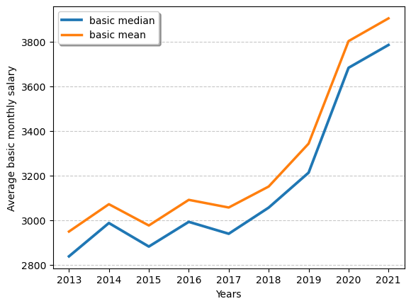

```python
#Accessing Column
basic_mean = employment['basic_monthly_mean']
basic_median = employment['basic_monthly_median']
years = employment['year']


#Find unique years
unique_years = np.unique(years)

# Calculate the average basic mean for each unique year
average_basic_means = [np.nanmean(basic_mean[years == year]) for year in unique_years]

# Display the result without using zip
for i in range(len(unique_years)):
    year = unique_years[i]
    mean = average_basic_means[i]
    print(f"Year {int(year)}: Average Basic Mean {mean:.2f}")


# Calculate the average basic median for each unique year
average_basic_median = [np.mean(basic_median[years == year]) for year in unique_years]

#spacing
print("\n")

# Display the result
for i in range(len(unique_years)):
    year = unique_years[i]
    mean = average_basic_median[i]
    print(f"Year {int(year)}: Average Basic Median {mean:.2f}")

#initialise fig and ax
fig,ax = plt.subplots()

#setting xticks
ax.set_xticks(np.arange(len(unique_years)))
ax.set_xticklabels(unique_years)

#plotting
ax.plot(average_basic_median,label = "basic median",linewidth=2.7)
ax.plot(average_basic_means,label = "basic mean",linewidth=2.5)

#labelling axis
ax.set_xlabel("Years")
ax.set_ylabel("Average basic monthly salary")

#legend
legend = ax.legend(loc='upper left', shadow=True)

#Grid
plt.grid(axis='y', linestyle='--', alpha=0.7)

#show
plt.show()
```

# Graph 1 Analysis

The line graph you sent me shows the trends in postgraduate basic mean and median salaries in Singapore from 2013 to 2021. The basic mean salary is the average of all the salaries, while the median salary is the middle value when all the salaries are listed in order from lowest to highest.

# Graph 2: Correlation Between Postgraduate Gross Monthly Mean and Employment Rate (Scatter plot)

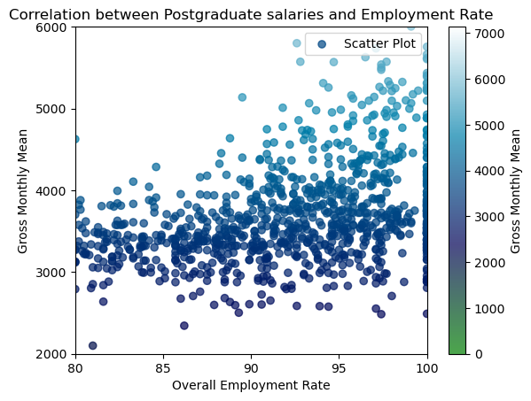

```python
# Accessing column
gross_monthly_mean = employment['gross_monthly_mean']
employment_rate = employment['employment_rate_overall']

# Create a color gradient based on gross_monthly_mean values
colors = gross_monthly_mean

# Setting X ticks and Y ticks
custom_xticks = range(80, 101, 5)
custom_yticks = range(2000, 7000, 1000)

#Add x and y ticks
plt.xticks(custom_xticks)
plt.yticks(custom_yticks)

# Set x and y axis limits to better fit the data
plt.xlim(80, 100)
plt.ylim(2000, 6000)

# Label the plot
plt.title('Correlation between Postgraduate salaries and Employment Rate')
plt.xlabel('Overall Employment Rate')
plt.ylabel('Gross Monthly Mean')

# Show the scatter plot with color gradation and legend
sc = plt.scatter(employment_rate, gross_monthly_mean, c=colors, cmap='ocean', marker='o', alpha=0.7)

# Add colorbar
cbar = plt.colorbar(sc)
cbar.set_label('Gross Monthly Mean')

# Add legend
plt.legend(['Scatter Plot'], loc='upper right')

# Show the plot
plt.show()
```

# Graph 2 Analysis

Overall trend: There appears to be a weak positive correlation between postgraduate gross monthly mean salary and employment rate. This means that as the employment rate increases, the average postgraduate salary also tends to increase, but the relationship is not very strong.

Data distribution: The data points are somewhat clustered in the middle, with fewer points at the extremes. This suggests that most postgraduate salaries and employment rates fall within a relatively narrow range

Outliers: There are a few outliers in the data, both above and below the main trend. These outliers could represent postgraduate fields with either exceptionally high salaries or low employment rates, or they could be due to other factors.

# Graph 3: Comparison of Average Postgraduate Gross Monthly Median in Different Universities (Bar Chart)

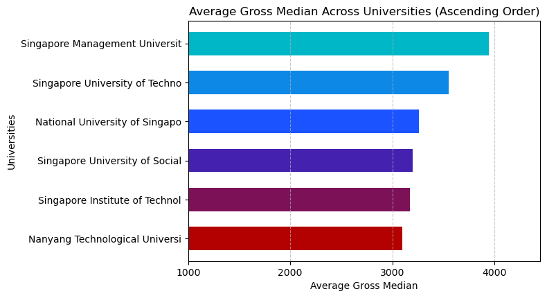

```python
# Accessing Column
gross_monthly_median = employment['gross_monthly_median']
university_not_unique = employment['university']

# Unique universities
universities = np.unique(university_not_unique)

# Finding average gross median
average_gross_median = [np.mean(gross_monthly_median[university_not_unique == university]) for university in universities]

# Sort universities based on average gross median in ascending order
ascending_sort = np.argsort(average_gross_median)[::-1]
sorted_indices = np.flip(ascending_sort)
universities = universities[sorted_indices]
average_gross_median = np.array(average_gross_median)[sorted_indices]

# Increased bar width for better visibility
width = 0.6

#Setting Colors used
colors = ["#b30000", "#7c1158", "#4421af", "#1a53ff", "#0d88e6", "#00b7c7", "#5ad45a", "#8be04e", "#ebdc78"]

#Intialise fig and ax
fig, ax = plt.subplots(figsize=(8, len(universities) * 0.7))

#Horizontal Bar
bars = ax.barh(universities, average_gross_median, height=width, color=colors)  # Use barh for horizontal bar chart

# Setting x and y label
ax.set_xlabel('Average Gross Median')
ax.set_ylabel("Universities")

# Set x-axis limits to start from 1000
ax.set_xlim(1000, max(average_gross_median) + 500)  # Adjust the upper limit as needed

# Adjust layout to prevent label overlapping
plt.tight_layout()

# Add grid for better readability
ax.grid(axis='x', linestyle='--', alpha=0.7)

# Add a title
plt.title('Average Gross Median Across Universities (Ascending Order)')

# Customize ticks
ax.set_xticks(np.arange(1000, max(average_gross_median) + 1000, 1000))

# Display the plot
plt.show()
```

# Graph 3 Analysis

From the graph above, it can be seen that postgraduates from different universities have different average gross median montly.

Postgraduates from Singapore Management University (SMU) have the highest average gross median which is near to 4000 dollar while postgraduates from Nanyang Technological University (NTU) have the lowest average gross median monthly which is near to 3000 dollar.

This suggests that universities affect the postgraduate salaries.

# 2) Does institutions with higher enrolment also produces higher graduates?

# Graph 4: Distribution of Graduates and Enrolment by Institutions (Histogram)

[figure not shown]

```python
# Pre-condition
start_year = 2013
end_year = 2021
sex = 'MF'
universities = ['nus', 'ntu', 'smu', 'sit', 'sutd', 'suss', 'nie', 'lasalle_degree', 'nafa_degree']

#Masking
mask = (graduates['year'].astype(int) >= 2013) & (graduates['year'].astype(int) <= 2021) & (graduates['sex'] == 'MF')
mask_enrollment = (enrollment['year'].astype(int) >= 2013) & (enrollment['year'].astype(int) <= 2021) & (enrollment['sex'] == 'MF')

#Filtered Result
filtered_graduates = graduates[mask]
filtered_enrollment = enrollment[mask_enrollment]

#Initialising List
results_graduates = []
results_enrollment = []


# Calculate and append results for each university
for university in universities:
    total = np.sum(filtered_graduates[university].astype(int))
    results_graduates.append(total)

# Calculate and append results for each university
for university in universities:
    total = np.sum(filtered_enrollment[university].astype(int))
    results_enrollment.append(total)


#For Labelling with Letter Case
institutions = ['NUS', 'NTU', 'SMU', 'SIT', 'SUTD', 'SUSS', 'NIE', 'Lasalle \nDegree', 'NAFA \nDegree']

#Convert Results to Numpy Array
graduates_array = np.array(results_graduates)
enrollment_array = np.array(results_enrollment)

# Create separate histograms for Graduates and Enrolled Students
fig, (ax1, ax2) = plt.subplots(nrows=1, ncols=2, figsize=(15, 6))

# Histogram for Graduates
ax1.hist(np.arange(len(institutions)) - 0.2, bins=np.arange(len(institutions)),
         weights=graduates_array, label='Graduates', color='blue', alpha=0.7)
ax1.set_xlabel('Institutions')
ax1.set_ylabel('Number of Graduates')
ax1.set_title('Distribution of Graduates by Institution over 9 years')
ax1.set_xticks(np.arange(len(institutions)))
ax1.set_xticklabels(institutions, ha='center')
ax1.legend()
ax1.grid(axis='y', linestyle='--', alpha=0.7)

# Histogram for Enrolled Students
ax2.hist(np.arange(len(institutions)) + 0.2, bins=np.arange(len(institutions)),
         weights=enrollment_array, label='Enrolled Students', color='green', alpha=0.7)
ax2.set_xlabel('Institutions')
ax2.set_ylabel('Number of Enrolled Students')
ax2.set_title('Distribution of Enrolled Students by Institution over 9 years')
ax2.set_xticks(np.arange(len(institutions)))
ax2.set_xticklabels(institutions, ha='center')
ax2.legend()
ax2.grid(axis='y', linestyle='--', alpha=0.7)

# Show the histograms
plt.tight_layout()
plt.show()
```

# Graph 4 Analysis

The graph show the distribution of graduates and enrolled students of 9 universities over 9 years.

From the graph, we can that the distribution of graduates and the distribution of enrolled students are positively-skewed distribution (skewed to right).

This suggests that there may be a few universities that have a disproportionately large number of enrolment compared to their graduation, while most universities have a more balanced ratio of graduates to enrolled students.

# Graph 5: Proportion of Graduates over Enrolment (Graduation Rate) in Each Institutions over nine years (2013-2021) (Pie Chart)

```
Total Graduates over 9 years of NUS, NTU, SMU, SIT, SUTD, SUSS, NIE, Lasalle Degree, NAFA Degree: [58625, 53773, 16009, 14003, 2398, 1319, 13919, 3965, 210]

Total Enrollment over 9 years of NUS, NTU, SMU, SIT, SUTD, SUSS, NIE, Lasalle Degree, NAFA Degree: [256758, 209447, 73920, 53896, 11853, 14512, 12857, 11277, 627]

Graduation Rate over 9 years NUS, NTU, SMU, SIT, SUTD, SUSS, NIE, Lasalle Degree, NAFA Degree: [22.832784178097665, 25.67379814463802, 21.657196969696972, 25.98151996437584, 20.231165105880365, 9.089029768467476, 108.26009177879754, 35.1600602997251, 33.49282296650718]


Note: Graduation Rate over 9 years = (Total number of graduates / Total number of enrolment) *100
```

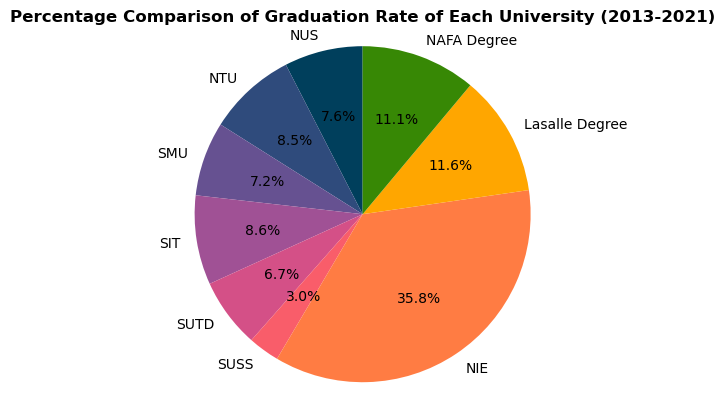

```python
# Pre-condition
start_year = 2013
end_year = 2021
sex = 'MF'
universities = ['nus', 'ntu', 'smu', 'sit', 'sutd', 'suss', 'nie', 'lasalle_degree', 'nafa_degree']

#Masking
mask = (graduates['year'].astype(int) >= 2013) & (graduates['year'].astype(int) <= 2021) & (graduates['sex'] == 'MF')
mask_enrollment = (enrollment['year'].astype(int) >= 2013) & (enrollment['year'].astype(int) <= 2021) & (enrollment['sex'] == 'MF')

#Filtered Result
filtered_graduates = graduates[mask]
filtered_enrollment = enrollment[mask_enrollment]

#Initialising List
results_graduates = []
results_enrollment = []


# Calculate and append results for each university
for university in universities:
    total = np.sum(filtered_graduates[university].astype(int))
    results_graduates.append(total)

# Calculate and append results for each university
for university in universities:
    total = np.sum(filtered_enrollment[university].astype(int))
    results_enrollment.append(total)

#Create Graduation Rate((Total number of graduates / Total number of enrolment) *100)
results_ratio_percentage = [ratio * 100 for ratio in [graduates / enrollment if enrollment != 0 else 0 for graduates, enrollment in zip(results_graduates, results_enrollment)]]


#Show Relevant Information
print(f'Total Graduates over 9 years of NUS, NTU, SMU, SIT, SUTD, SUSS, NIE, Lasalle Degree, NAFA Degree: {results_graduates}', '\n')

print(f'Total Enrollment over 9 years of NUS, NTU, SMU, SIT, SUTD, SUSS, NIE, Lasalle Degree, NAFA Degree: {results_enrollment}', '\n')

print(f'Graduation Rate over 9 years NUS, NTU, SMU, SIT, SUTD, SUSS, NIE, Lasalle Degree, NAFA Degree: {results_ratio_percentage}', '\n')

print('\nNote: Graduation Rate over 9 years = (Total number of graduates / Total number of enrolment) *100')


# Create labels and colors
labels = ['NUS', 'NTU', 'SMU', 'SIT', 'SUTD', 'SUSS', 'NIE', 'Lasalle Degree', 'NAFA Degree']
colors = ['#003f5c', '#2f4b7c', '#665191', '#a05195', '#d45087', '#f95d6a', '#ff7c43', '#ffa600', '#378805']

#Initialise fig and ax
fig, ax = plt.subplots()

#Piechart
ax.pie(results_ratio_percentage, labels=labels, autopct='%1.1f%%', startangle=90 , colors = colors)
ax.axis('equal')  # Equal aspect ratio ensures that pie is drawn as a circle.

#Add title
plt.title('Percentage Comparison of Graduation Rate of Each University (2013-2021)', fontweight='bold')

#Display the plot
plt.show()
```

# Graph 5 Analysis

The pie chart you sent me shows the graduation rate of nine Singaporean universities and art schools over a nine-year period (2013-2021). The graduation rate is calculated as the total number of graduates divided by the total number of enrollees over the nine-year period.

The National Institute of Education (NIE) has the highest graduation rate, at 108.26% and 35.8% comparing with other universities as seen from the graph. The Singapore University of Social Sciences (SUSS) has the lowest graduation rate, at 9.09% and 3.0% comparing with other universities as seen from the graph.

The pie chart also shows that there is no clear correlation between enrollment and graduation rate. For example, NUS, which has the highest enrollment, does not have the highest graduation rate. Similarly, NTU, which has the second-highest enrollment, does not have the second-highest graduation rate.

# 1) What are the factors affecting post graduate salaries?

From graph 2, we can see there is a positive trend in the correlation between employment rate and post graduate salaries. Even though the relationship is not strong, employment rate still does contribute to the factor affecting the postgraduate salaries to a certain extent.

From graph 3, we can see that the average gross median of post graduate salaries is different in different universities. Hence, it shows that university is one of the factor affecting post graduate salaries.

In summary, there are several factors affecting post graduate salaries. From the analysis gained from graph 1,2,and 3, we therefore can infer that time, employment rate, and universities do affect the post graduate salaries to a certain extent.

# 2) Does institutions with higher enrolment also produces higher graduates?